[OHI British Columbia](http://www.ohibc.org/) | [OHI Science](http://ohi-science.org) | [Citation policy](https://github.com/OHI-Science/ohiprep/releases)

# OHIBC: Pathogens Pressure layers prep

Compiled on Tue Dec 19 19:47:09 2017 by ohara

# 1 Summary

This pressure layer determines potential for human pathogen contamination using census district populations, statistics on percent of population with improved sanitation (by province and by municipality size), and modeled population density. The model compares the population density of higher-risk wastewater systems (e.g. septic, storage/haulage) to a reference point of the highest density region being entirely on higher-risk systems.

$$X_{pathogens} = \frac{\delta_{at-risk,rgn}}{\delta_{all,max}}$$
where $\delta_{at-risk,rgn}$ represents a region’s population on systems, divided by the region area:

$$\delta_{at-risk,rgn} = Population_{at-risk,rgn} / A_{rgn}$$

and $\delta_{all,max}$ represents the max overall population density of any OHIBC region.

$$\delta_{all,max} = (Population_{all} / A_{rgn})_{max}$$

# 2 Data

**Census subdivision administrative boundaries**

- **Reference**: [Copyright © 2017, Province of British Columbia](http://www2.gov.bc.ca/gov/content/home/copyright)
- **Downloaded**: Aug 7, 2017 from:
  - http://www12.statcan.gc.ca/census-recensement/2011/geo/bound-limit/bound-limit-2016-eng.cfm (2016 census subdivisions)
  - http://www2.gov.bc.ca/gov/content/data/geographic-data-services/land-use/administrative-boundaries (2011 census subdivisions)
  - http://www12.statcan.gc.ca/census-recensement/2011/geo/bound-limit/bound-limit-2006-eng.cfm (2006 census subdivisions)
  - http://www12.statcan.gc.ca/census-recensement/2011/geo/bound-limit/bound-limit-2001-eng.cfm (2001 census subdivisions)
- **Description**: Census subdivision administrative boundaries; choose “English”, “ArcGIS” (or “ARC/INFO” for 2001), census subdivisions, cartographic boundary file option)
- **Native data resolution**: Census subdivision
- **Format**: ESRI shapefile (or Arc e00 file for 2001)

**2011 and 2016 Census Total Population Results Census Subdivisions**

- **Reference**: [Statistics Canada, Prepared by: BC Stats, Ministry of Technology, Innovation and Citizens’ Services]
- **Downloaded**: Aug 7, 2017 from
  - http://www.bcstats.gov.bc.ca/StatisticsBySubject/Census/2001Census/PopulationHousing/CensusSubdivisions.aspx (2001)
  - http://www.bcstats.gov.bc.ca/StatisticsBySubject/Census/2006Census/PopulationHousing/CensusSubdivisions.aspx (2006)
  - http://www.bcstats.gov.bc.ca/StatisticsBySubject/Census/2011Census/PopulationHousing/CensusSubdivisions.aspx (2011)
  - http://www.bcstats.gov.bc.ca/StatisticsBySubject/Census/2016Census/PopulationHousing/CensusSubdivisions.aspx (2016)
- **Description**: Census subdivision populations for 2001, 2006, 2011, 2016
- **Native data resolution**: Census subdivision (note boundaries are different each year, use proper shapefile)
- **Format**: .csv

**Municipal Water Use Report – Municipal Water Use Statistics**

- **Reference**: [Copyright © 2017, Province of British Columbia](http://www2.gov.bc.ca/gov/content/home/copyright)
- **Downloaded**: Aug 7, 2017 from:
  - http://www.ec.gc.ca/doc/publications/eau-water/COM1454/survey8-eng.htm#table3_toc (2011, from 2009 data)
  - http://publications.gc.ca/collections/collection_2010/ec/En11-2-2006-eng.pdf (2006 data)
  - http://publications.gc.ca/collections/collection_2010/ec/En11-2-2004-eng.pdf (2004 data)
- **Description**: Percent populations served by sewers, by province and by municipality size
- **Native data resolution**: Province and municipality size division
- **Format**: web page

**National Assessment of First Nations Water and Wastewater Systems - National Roll-Up Report**

- **Reference**: [Indigenous and Northern Affairs Canada](http://www.aadnc-aandc.gc.ca/eng/1100100010002/1100100010021)
- **Downloaded**: Aug 7, 2017 from http://www.aadnc-aandc.gc.ca/eng/1313770257504/1313770328745#tab3_5
- **Description**: Summary of Overall Risk by Region – Wastewater
- **Native data resolution**: Province
- **Format**: web page

# 3 Methods

## 3.1 Determine populations on various levels of sewer service

Based on the [2011 Municipal Water Use Report](http://www.ec.gc.ca/doc/publications/eau-water/COM1454/survey8-eng.htm#table3_toc) we can approximately determine the population of people in each municipality on various levels of sewer service (sewer, septic, holding tanks). Aggregating these up to OHIBC regions allows us to determine region-wide populations served by these methods.

### 3.1.1 Determine population trend over time

The above calculations are all based on populations in 2011. To create a time series, we will hold constant the proportion of population on each wastewater system; data for changes in systems over time are not available.

Using census data from multiple years, we aggregate census district population data to rescale populations over time.

Here we combine the population dataframe with the CSD dataframe to calculate total First Nations and non-First Nations populations in each OHIBC region.

The data from the Municipal Waste Water Survey exclude municipalities on federal lands and First Nations communities. These can be identified from the census data using the “type” codes (and an older code of “R” seems to indicate First Nations as well prior to 2006):

| CSD type | Description |
| --- | --- |
| CY | City |
| DM | District Municipality |
| T | Town |
| VL | Village |
| IM | Island Municipality |
| IRI ✓ | Indian Reserve |
| RDA | Regional District Electoral Area |
| IGD ✓ | Indian Governmental District |
| S-E ✓ | Indian Settlement |
| NL ✓ | Nisga’a Land |
| NVL ✓ | Nisga’a Village |

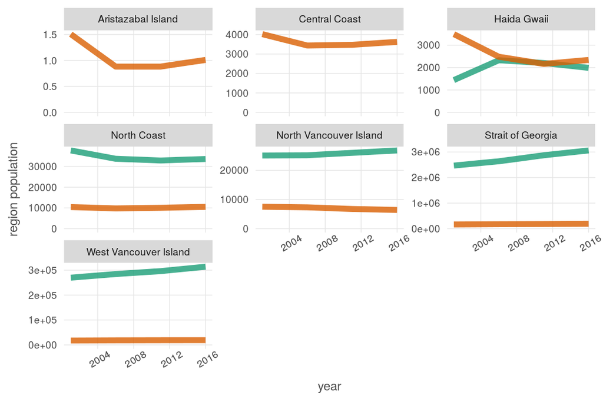

### 3.1.2 Determine population of municipalities within OHIBC

Develop a dataframe of municipalities by OHIBC region (inland, based on MaPP inland regions and watershed boundaries). Census subdivisions will be allocated to OHIBC regions according to area-weighting.

Assign 2001/2006/2011/2016 population statistics to each census subdivision. Result is a dataframe of OHIBC region, and population by municipality size category by year.

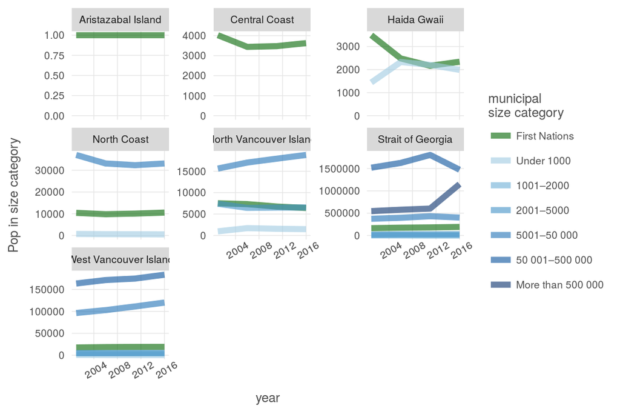

|  | rgn_id | pop_cat | year | pop_in_pop_cat |
| --- | --- | --- | --- | --- |
| 1 | 1 | 5001–50 000 | 2001 | 37037 |
| 2 | 1 | 5001–50 000 | 2006 | 33122 |
| 3 | 1 | 5001–50 000 | 2011 | 32329 |
| 4 | 1 | 5001–50 000 | 2016 | 33118 |
| 5 | 1 | First Nations | 2001 | 10414 |
| 6 | 1 | First Nations | 2006 | 9784 |
| 7 | 1 | First Nations | 2011 | 10073 |
| 8 | 1 | First Nations | 2016 | 10529 |
| 9 | 1 | Under 1000 | 2001 | 704 |
| 10 | 1 | Under 1000 | 2006 | 611 |

[output cut: 87 more lines]

### 3.1.3 Assign sewer service levels to OHIBC regions

The data from the Municipal Waste Water Survey exclude municipalities on federal lands and First Nations communities. For these municipalities, we have rough information on “high” “medium” and “low” risk systems from National Assessment of First Nations Water and Wastewater Systems report, [Table 3.5 – Summary of Overall Risk by Region – Wastewater](http://www.aadnc-aandc.gc.ca/eng/1313770257504/1313770328745#tab3_5), and a digitized map from [Figure 3.5 – Community Wastewater Systems By Risk](http://www.aadnc-aandc.gc.ca/eng/1313770257504/1313770328745#fig3_5) (note, digitized from the PDF which is at higher resolution than the website).

#### 3.1.3.1 Determine First Nations waste water risk by region

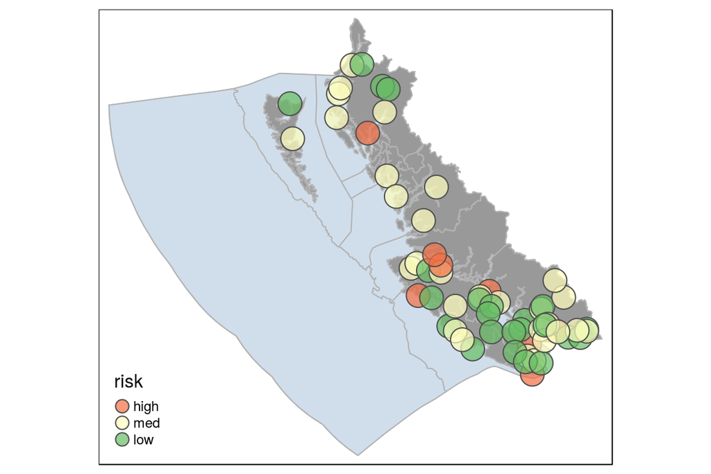

| rgn_id | system_ratings | percent_high_risk |
| --- | --- | --- |
| 1 | high = 1; med = 5; low = 3 | 0.3889 |
| 2 | med = 1; low = 1 | 0.2500 |
| 3 | med = 4 | 0.5000 |
| 4 | high = 2; med = 4; low = 1 | 0.5714 |
| 5 | high = 2; med = 3; low = 6 | 0.3182 |
| 6 | high = 3; med = 12; low = 12 | 0.3333 |

#### 3.1.3.2 Combine with non-First Nations waste water services

Calculate population served by sewers for non-First Nations (using population %ages from MWWS survey), then for First Nations (using mean of high/med/low risk values). MWWS survey values will be roughly assigned to years as:

- 2001 will be assigned 2004 survey results.
- 2006 will be assigned 2006 survey results.
- 2011 and 2016 will be assigned 2009 survey results.

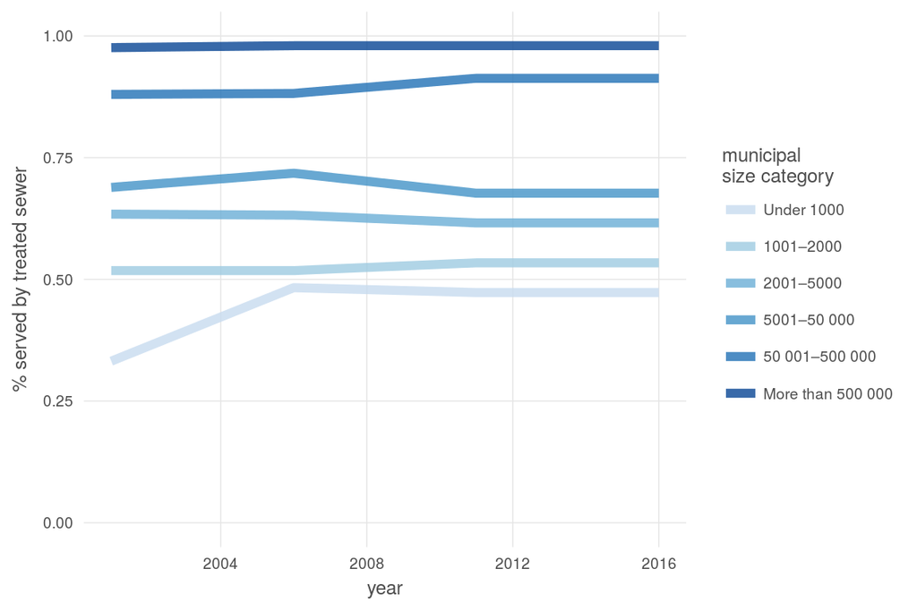

|  | rgn_id | year | pop_cat | pct_treated | pop_in_cat | pop_treated |
| --- | --- | --- | --- | --- | --- | --- |
| 1 | 1 | 2001 | 5001–50 000 | 0.689 | 37037 | 25518.493 |
| 2 | 1 | 2001 | Under 1000 | 0.332 | 704 | 233.728 |
| 3 | 1 | 2006 | 5001–50 000 | 0.718 | 33122 | 23781.596 |
| 4 | 1 | 2006 | Under 1000 | 0.483 | 611 | 295.113 |
| 5 | 1 | 2011 | 5001–50 000 | 0.677 | 32329 | 21886.733 |
| 6 | 1 | 2011 | Under 1000 | 0.473 | 574 | 271.502 |
| 7 | 1 | 2016 | 5001–50 000 | 0.677 | 33118 | 22420.886 |
| 8 | 1 | 2016 | Under 1000 | 0.473 | 508 | 240.284 |
| 9 | 2 | 2001 | Under 1000 | 0.332 | 1442 | 478.744 |
| 10 | 2 | 2006 | Under 1000 | 0.483 | 2328 | 1124.424 |

[output cut: 87 more lines]

## 3.2 Calculate pathogen pressures for OHIBC regions

Our pressure model will be based on population density on high-risk wastewater systems:

- A pressure of zero means the entire population (regardless of density) is on sewer or low-risk systems.
- As (Population density * percent at risk) climbs, pressure climbs.
- Reference point is the population density of the most dense OHIBC region, as if that region were entirely on high-risk systems.

At this point we also remove Aristazabal Island from the pathogen calculations because it is essentially unpopulated.

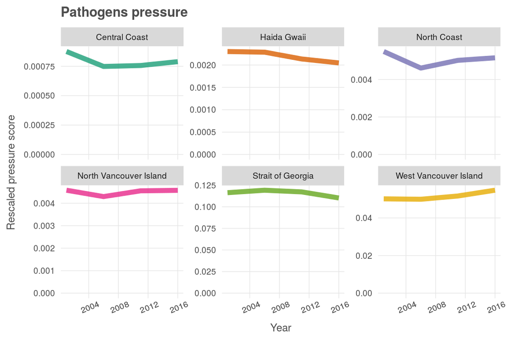

# 4 Provenance

- *Run ID: 3 (2913461); run tag: “standard run”*
- *Run elapsed time: 89.344 seconds; run memory usage: 4091.1 MB*
- *System info:*
  - *System: Linux, Release: 4.4.0-57-generic. Machine: x86_64. User: ohara.*
  - *R version: R version 3.4.3 (2017-11-30), Platform: x86_64-pc-linux-gnu, Running under: Ubuntu 14.04.5 LTS.*
  - *Attached base packages: stats, graphics, grDevices, utils, datasets, methods, base*
  - *Other attached packages: tmap_1.10, bindrcpp_0.2, provRmd_0.1.1, stringr_1.2.0, RColorBrewer_1.1-2, dplyr_0.7.2, purrr_0.2.3, readr_1.1.0, tidyr_0.7.0, tibble_1.3.4, ggplot2_2.2.1.9000, tidyverse_1.1.1, sf_0.5-5*

[figure not shown]

| sequence | file_name | parent_chunk | file_dir | filetype | uncomm_chgs | commit_hash_short |
| --- | --- | --- | --- | --- | --- | --- |
| 0 | cw_pathogens_prep.Rmd | unnamed-chunk-1 | ~/github/ohibc/prep/cw/v2017 | parent_script | True | f48958d |
| 0 | cw_pathogens_prep.Rmd#attach_percents_to_pops | attach_percents_to_pops | ~/github/ohibc/prep/cw/v2017 | parent_chunk | True | f48958d |
| 0 | cw_pathogens_prep.Rmd#calc_pressures | calc_pressures | ~/github/ohibc/prep/cw/v2017 | parent_chunk | True | f48958d |
| 0 | cw_pathogens_prep.Rmd#census_pops_2001_2016 | census_pops_2001_2016 | ~/github/ohibc/prep/cw/v2017 | parent_chunk | True | f48958d |
| 0 | cw_pathogens_prep.Rmd#ohibc_pop_by_municipality_size | ohibc_pop_by_municipality_size | ~/github/ohibc/prep/cw/v2017 | parent_chunk | True | f48958d |
| 0 | cw_pathogens_prep.Rmd#plot_pressures | plot_pressures | ~/github/ohibc/prep/cw/v2017 | parent_chunk | True | f48958d |
| 0 | cw_pathogens_prep.Rmd#pop_served_by_sewers | pop_served_by_sewers | ~/github/ohibc/prep/cw/v2017 | parent_chunk | True | f48958d |
| 0 | cw_pathogens_prep.Rmd#read_pop_data_2001-2016 | read_pop_data_2001-2016 | ~/github/ohibc/prep/cw/v2017 | parent_chunk | True | f48958d |
| 0 | cw_pathogens_prep.Rmd#setup | setup | ~/github/ohibc/prep/cw/v2017 | parent_chunk | True | f48958d |
| 0 | cw_pathogens_prep.Rmd#spatialize_fn_risk | spatialize_fn_risk | ~/github/ohibc/prep/cw/v2017 | parent_chunk | True | f48958d |

[output cut: 26 more lines]